# Hyperparameter Tuning

Author

Yazeed Aljohani

```r
library(tidyverse)
library(tidymodels)
library(skimr)
library(visdat)
library(ggpubr)
library(powerjoin)
library(patchwork)
library(ggthemes)
```

```r
# Download the PDF documentation
pdf_url <- "https://gdex.ucar.edu/dataset/camels/file/camels_attributes_v2.0.pdf"
download.file(pdf_url, destfile = "data/camels_attributes_v2.0.pdf")

# Download all data types
root <- 'https://gdex.ucar.edu/dataset/camels/file'
types <- c("clim", "geol", "soil", "topo", "vege", "hydro")
remote_files <- paste0(root, "/camels_", types, ".txt")
local_files  <- paste0("data/camels_", types, ".txt")
walk2(remote_files, local_files, download.file, quiet = TRUE)

# Read and merge the data
camels <- map(local_files, read_delim, show_col_types = FALSE)
camels <- power_full_join(camels, by = 'gauge_id')

# Add log of q_mean
camels <- camels |> mutate(logQmean = log(q_mean))
```

```r
set.seed(101)
split <- initial_split(camels, prop = 0.75)
train <- training(split)
test <- testing(split)
cv <- vfold_cv(train, v = 10)
```

```r
my_recipe <- recipe(logQmean ~ aridity + p_mean + elev_mean + slope_mean, data = train) |>
  step_log(all_predictors()) |>
  step_normalize(all_predictors()) |>
  step_naomit(all_predictors(), all_outcomes())
```

### Defining a tunable model

```r
# Defining a tunable XGBoost model
xgb_tune <- boost_tree(
  trees = tune(),
  learn_rate = tune(),
  tree_depth = tune()
) |>
  set_engine("xgboost") |>
  set_mode("regression")
```

### Creating a workflow for tuning

```r
# Using the same recipe from Lab 6
wf_tune <- workflow() |>
  add_model(xgb_tune) |>
  add_recipe(my_recipe)
```

### Exploring tunable hyperparameter ranges

```r
dials <- extract_parameter_set_dials(wf_tune)
dials
```

```
Collection of 3 parameters for tuning
```

```
 identifier       type    object
      trees      trees nparam[+]
 tree_depth tree_depth nparam[+]
 learn_rate learn_rate nparam[+]
```

### Creating the search grid

```r
# Create a Latin Hypercube grid
set.seed(123)
my.grid <- grid_latin_hypercube(dials, size = 25)
```

### Tuning the model using the grid

```r
# Tune over the resamples
model_params <- tune_grid(
  wf_tune,
  resamples = cv,  # from Lab 6
  grid = my.grid,
  metrics = metric_set(rmse, rsq, mae),
  control = control_grid(save_pred = TRUE)
)
```

### Visualize tuning results

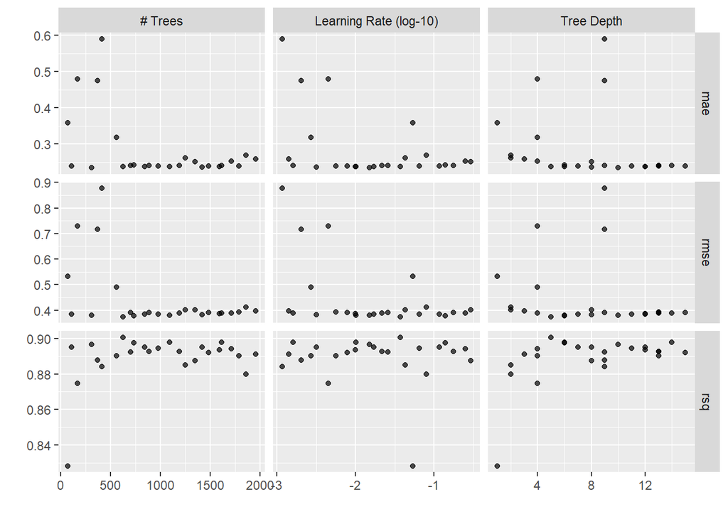

```r
autoplot(model_params)
```

```r
collect_metrics(model_params) |>
  arrange(mean)
```

```
# A tibble: 75 × 9
   trees tree_depth learn_rate .metric .estimator  mean     n std_err .config
   <int>      <int>      <dbl> <chr>   <chr>      <dbl> <int>   <dbl> <chr>
 1   306         10    0.0149  mae     standard   0.235    10  0.0155 Preproces…
 2  1415          8    0.00317 mae     standard   0.236    10  0.0150 Preproces…
 3  1589         12    0.00993 mae     standard   0.237    10  0.0169 Preproces…
 4   842         12    0.0171  mae     standard   0.237    10  0.0173 Preproces…
 5  1090          6    0.0101  mae     standard   0.238    10  0.0146 Preproces…
 6   621          5    0.0371  mae     standard   0.238    10  0.0146 Preproces…
 7   977         11    0.0649  mae     standard   0.238    10  0.0173 Preproces…
 8  1483         15    0.00787 mae     standard   0.239    10  0.0174 Preproces…
 9   109          7    0.117   mae     standard   0.239    10  0.0165 Preproces…
10  1786         13    0.00562 mae     standard   0.240    10  0.0164 Preproces…
# ℹ 65 more rows
```

```r
show_best(model_params, metric = "mae")
```

```
# A tibble: 5 × 9
  trees tree_depth learn_rate .metric .estimator  mean     n std_err .config
  <int>      <int>      <dbl> <chr>   <chr>      <dbl> <int>   <dbl> <chr>
1   306         10    0.0149  mae     standard   0.235    10  0.0155 Preprocess…
2  1415          8    0.00317 mae     standard   0.236    10  0.0150 Preprocess…
3  1589         12    0.00993 mae     standard   0.237    10  0.0169 Preprocess…
4   842         12    0.0171  mae     standard   0.237    10  0.0173 Preprocess…
5  1090          6    0.0101  mae     standard   0.238    10  0.0146 Preprocess…
```

```r
hp_best <- select_best(model_params, metric = "mae")
```

After tuning the XGBoost model, the best combination of hyperparameters included 306 trees, a tree depth of 10, and a learning rate around 0.015. This setup gave the lowest mean absolute error (MAE) of about 0.235 during cross-validation. What stood out to me is that the top few combinations all performed pretty similarly, which makes me feel more confident that the model is stable and not just getting lucky with one specific set of values.

### Finalizing the workflow

```r
final_wf <- finalize_workflow(wf_tune, hp_best)
```

### Fitting and evaluate on the test set

```r
final_fit <- last_fit(final_wf, split)

# Metrics
collect_metrics(final_fit)
```

```
# A tibble: 2 × 4
  .metric .estimator .estimate .config
  <chr>   <chr>          <dbl> <chr>
1 rmse    standard       0.354 Preprocessor1_Model1
2 rsq     standard       0.912 Preprocessor1_Model1
```

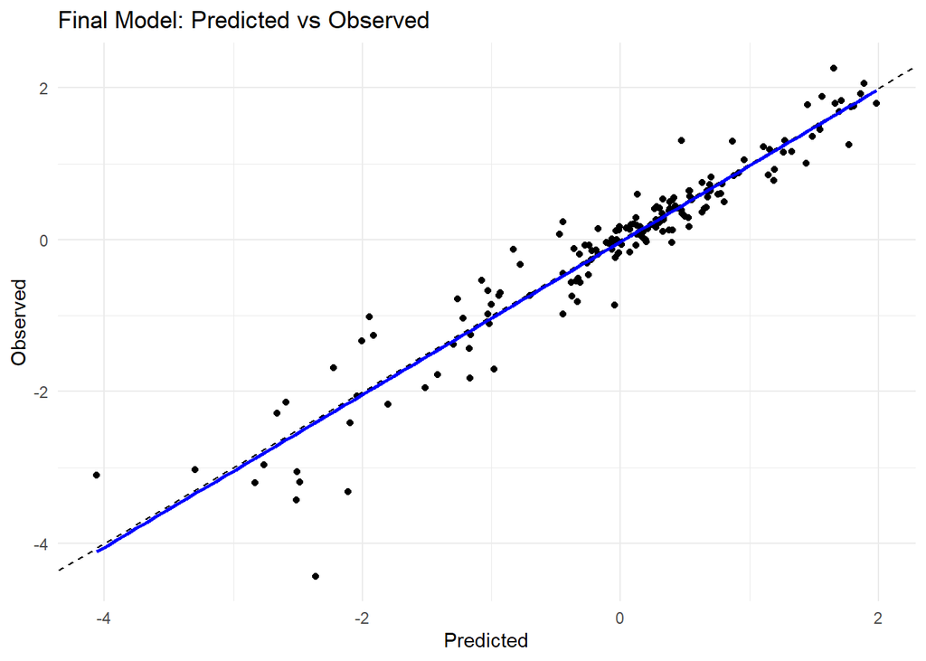

```r
# Predictions
preds <- collect_predictions(final_fit)

# Plot predicted vs actual
ggplot(preds, aes(x = .pred, y = logQmean)) +
  geom_point() +
  geom_abline(linetype = "dashed") +
  geom_smooth(method = "lm", se = FALSE, color = "blue") +
  labs(title = "Final Model: Predicted vs Observed", x = "Predicted", y = "Observed") +
  theme_minimal()
```

When I tested the final model on the test dataset, it had an RMSE of about 0.354 and an R² of 0.912. That means it explained more than 91% of the variation in logQmean, which I think is a strong result for this kind of regression problem. The low RMSE also tells me the model’s predictions are pretty close to the actual values. So overall, I’d say it generalizes well and didn’t just perform well during training.

The scatter plot of predicted vs actual logQmean shows a really tight alignment along the 1:1 line. That tells me the model is doing a solid job — it’s not systematically overpredicting or underpredicting. I also added a smoothed line with geom_smooth(), and it basically follows the diagonal, which is a good sign that the model is learning the overall pattern accurately.

### Mapping predictions and residuals

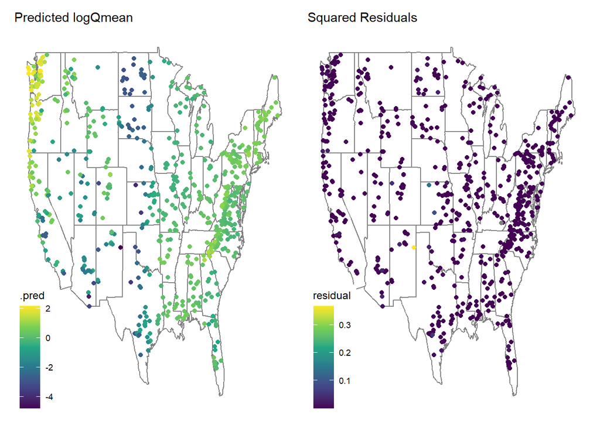

```r
# Fit to full dataset
fit_final <- fit(final_wf, data = camels)

# Augment with predictions
camels_aug <- augment(fit_final, new_data = camels) |>
  mutate(residual = (logQmean - .pred)^2)

# Plot predictions map
p_pred <- ggplot(camels_aug, aes(x = gauge_lon, y = gauge_lat, color = .pred)) +
  borders("state") +
  geom_point() +
  scale_color_viridis_c() +
  labs(title = "Predicted logQmean") +
  theme_map()

# Plot residuals map
p_resid <- ggplot(camels_aug, aes(x = gauge_lon, y = gauge_lat, color = residual)) +
  borders("state") +
  geom_point() +
  scale_color_viridis_c() +
  labs(title = "Squared Residuals") +
  theme_map()

# Combine maps
p_pred + p_resid
```

The map of predicted logQmean looks smooth and seems to reflect regional differences in climate or terrain across the U.S. I think this means the model picked up on some real geographic trends in streamflow. The residual map mostly shows small errors, though a few spots have higher values. Those might be sites where streamflow is influenced by something the model didn’t capture — like human intervention or more localized features. But overall, the model seems to do well across most areas.